# UNIVERSIDADE FEDERAL DE LAVRAS Geomática para Ambientes Tarefa 05

Vítor Ferreira

17/12/2023

## Introdução

Ao longo do semestre além das imagens oram recolhidos também pontos de temperatura, na lavoura. Essa prátia pretende trabalhar com os dados da terceira florada.

## Habilitar pacotes

Os pacotes terra, viridis e ggcorrplot são habilitados com a função library.

```r
library(terra)
library(viridis)
```

```r
library(ggcorrplot)
```

## Importar ortomosaico de imagem termal

O ortomosaico termal georreferenciado obtido no mesmo levantamento de dados é importado no R com a função rast.

```r
termal <- rast("/home/vitor/Disciplinas_especiais_UFLA/geomatica/imagem_drone/Florada_03/3_Florada_03112023/Campus-Ufla-03-11-2023-all-Termal/odm_orthophoto/termal.tif")
```

A composição de bandas obtidas após o ortomosaico é renomeada com a função names.

```r
names(termal) <- c("R", "G", "B", "I")
termal
```

```
## class       : SpatRaster
## dimensions  : 4070, 4223, 4  (nrow, ncol, nlyr)
## resolution  : 0.04999767, 0.04999282  (x, y)
## extent      : 502940, 503151.1, 7652677, 7652880  (xmin, xmax, ymin, ymax)
## coord. ref. : WGS 84 / UTM zone 23S (EPSG:32723)
## source      : termal.tif
## names       :   R,   G,   B,   I
## min values  :   0,   0,   0,   0
## max values  : 255, 255, 255, 255
```

## Importar dados de temperatura

Os dados de pontos de temperatura do ar obtidos com termômetro são importados com a função vect. O arquivo shp foi obtido em tarefas anteriores. Salvo em servidor local.

```r
tpt <- vect("/home/vitor/Disciplinas_especiais_UFLA/geomatica/shp/tpt.shp")
```

## Importar polígono com limites da lavoura

O polígono com limites da área é importado com a função vect. Também obitido em tarefas anteriores. Salvo em servidor local.

```r
pol <- vect("/home/vitor/Disciplinas_especiais_UFLA/geomatica/shp/pol.shp")
```

# Poligno e Pontos de Temperatura Abaixo um plot do poligno da lavoura e dos pontos de temperatura recolhidos.

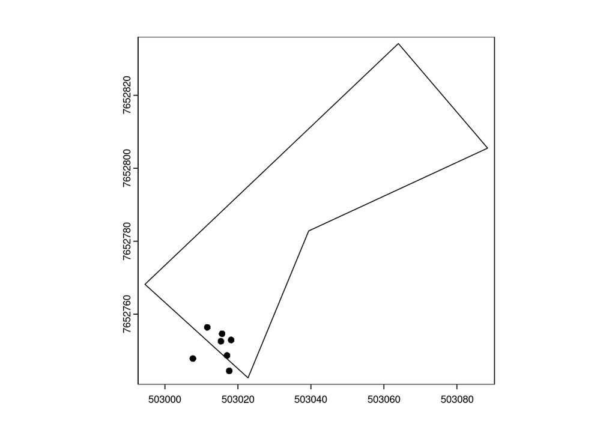

```r
plot(pol)
plot(tpt, add = T)
```

## Mapear todos os Dados

A imagem termal é mapeada com a função plotRGB. Os pontos de temperatura levantados na lavoura e o polígono ao redor da lavoura são mapeados com as funções points e polys, respectivamente.

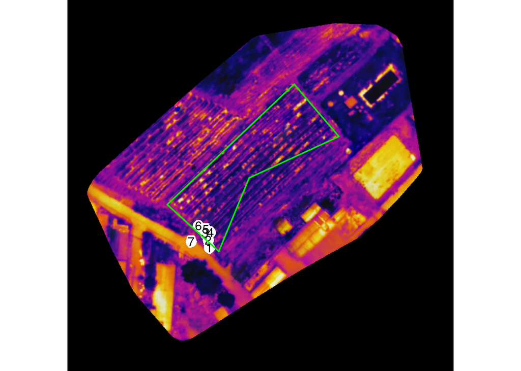

```r
plotRGB(termal, r = 1, g = 2, b = 3)
points(tpt, col = "white", cex = 2)
text(tpt, halo=TRUE, col="black", hw = 0.2)
polys(pol, col = "transparent", bor = "green2", lwd = 2)
```

## Extrair valores de raster por pontos

Os valores de temperatura são extraídos da imagem termal com a função extract.

```r
ptermal <- extract(termal, tpt)
```

Resultado dos dados extraídos.

```r
ptermal
```

```
##   ID   R  G   B   I
## 1  1 148 17 137 255
## 2  2  84 17 141 255
## 3  3 186 27 135 255
## 4  4  27 18  73 255
## 5  5 203 37 110 255
## 6  6  66 22 117 255
## 7  7 210 86  22 255
```

Os dados extraídos do imageamento termal são agregados na mesma tabela de atributos dos arquivos com valores de temperatura do ar. A coluna repetida de ID é removida da base de dados com operador de colchetes.

```r
tptrgb <- cbind(tpt, ptermal)
```

Verificando as propriedades do objeto.

```r
tptrgb
```

```
##  class       : SpatVector
##  geometry    : points
##  dimensions  : 7, 8  (geometries, attributes)
##  extent      : 503007.7, 503018.1, 7652744, 7652756  (xmin, xmax, ymin, ymax)
##  source      : tpt.shp
##  coord. ref. : WGS 84 / UTM zone 23S (EPSG:32723)
##  names       :    ID altitude temperatur    ID     R     G     B     I
##  type        : <int>    <num>      <num> <num> <num> <num> <num> <num>
##  values      :     1    940.6       31.5     1   148    17   137   255
##                    2    940.3       29.1     2    84    17   141   255
##                    3    940.1       34.3     3   186    27   135   255
```

Aplicando o operador de colchetes.

```r
tptrgb <- tptrgb[,-4]
```

Verificando as propriedades do objeto.

```r
tptrgb
```

```
##  class       : SpatVector
##  geometry    : points
##  dimensions  : 7, 7  (geometries, attributes)
##  extent      : 503007.7, 503018.1, 7652744, 7652756  (xmin, xmax, ymin, ymax)
##  source      : tpt.shp
##  coord. ref. : WGS 84 / UTM zone 23S (EPSG:32723)
##  names       :    ID altitude temperatur     R     G     B     I
##  type        : <int>    <num>      <num> <num> <num> <num> <num>
##  values      :     1    940.6       31.5   148    17   137   255
##                    2    940.3       29.1    84    17   141   255
##                    3    940.1       34.3   186    27   135   255
```

Os resultados podem ser exportados para diretório local com a função writeVector.

```r
writeVector(tptrgb, "/home/vitor/Disciplinas_especiais_UFLA/geomatica/shp/tptrgb.shp",
            overwrite = TRUE)
```

Um data.frame é obtido a partir do objeto SpatVector com a função as.data.frame. Com isso é possível realizar a modelagem de regressão múltipla para relacionar as bandas RGB do imageamento termal com os valores de temperatura do ar medidos no campo.

```r
tptrgbd <- as.data.frame(tptrgb)
```

Propriedades do objeto criado.

```r
tptrgbd
```

```
##   ID altitude temperatur   R  G   B   I
## 1  1  940.590       31.5 148 17 137 255
## 2  2  940.263       29.1  84 17 141 255
## 3  3  940.052       34.3 186 27 135 255
## 4  4  940.173       29.7  27 18  73 255
## 5  5  940.084       33.5 203 37 110 255
## 6  6  939.844       32.3  66 22 117 255
## 7  7  939.747       40.7 210 86  22 255
```

A função lm é utilizada para modelagem da relação entre o imageamento termal com os valores de temperatura do ar medidos no campo. Com o uso da função summary são observados a significância de parâmetros e a incerteza da modelagem com base em métricas de erro.

```r
model <- lm(formula = temperatur ~ R + G + B, data = tptrgbd)
```

Propiedades do objeto “model”.

```r
model
```

```
##
## Call:
## lm(formula = temperatur ~ R + G + B, data = tptrgbd)
##
## Coefficients:
## (Intercept)            R            G            B
##   26.992030     0.011800     0.129495     0.003055
```

```r
summary(model)
```

```
##
## Call:
## lm(formula = temperatur ~ R + G + B, data = tptrgbd)
##
## Residuals:
##        1        2        3        4        5        6        7
##  0.14157 -1.51544  1.20433 -0.16457 -1.01485  1.32281  0.02615
##
## Coefficients:
##              Estimate Std. Error t value Pr(>|t|)
## (Intercept) 26.992030   5.138140   5.253   0.0134 *
## R            0.011800   0.017603   0.670   0.5506
## G            0.129495   0.088609   1.461   0.2401
## B            0.003055   0.039824   0.077   0.9437
## ---
## Signif. codes:  0 '***' 0.001 '**' 0.01 '*' 0.05 '.' 0.1 ' ' 1
##
## Residual standard error: 1.48 on 3 degrees of freedom
## Multiple R-squared:  0.927,  Adjusted R-squared:  0.854
## F-statistic:  12.7 on 3 and 3 DF,  p-value: 0.03274
```

Os resíduos do modelo são obtidos com operador de cifrão ao explorar os resultados da modelagem

```r
model_residuals <- model$residuals
```

Verificando as propiedades do objeto.

```r
model_residuals
```

```
##           1           2           3           4           5           6
##  0.14157315 -1.51543906  1.20432725 -0.16457422 -1.01484668  1.32281210
##           7
##  0.02614746
```

Um histograma dos resíduos é realizado com a função hist.

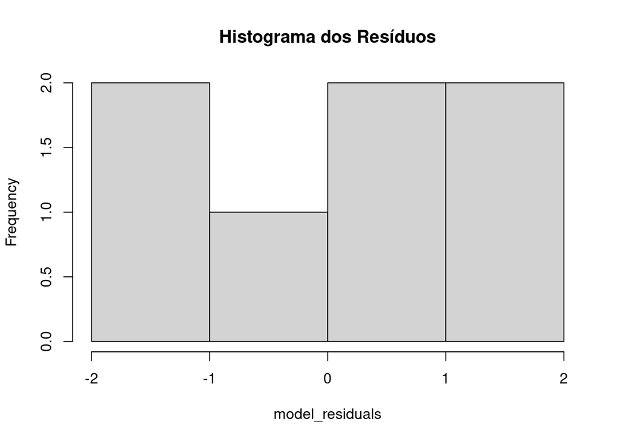

```r
hist(model_residuals, main = "Histograma dos Resíduos")
```

A função qqnorm é utilizada para representação de resíduos em formato gráfico.

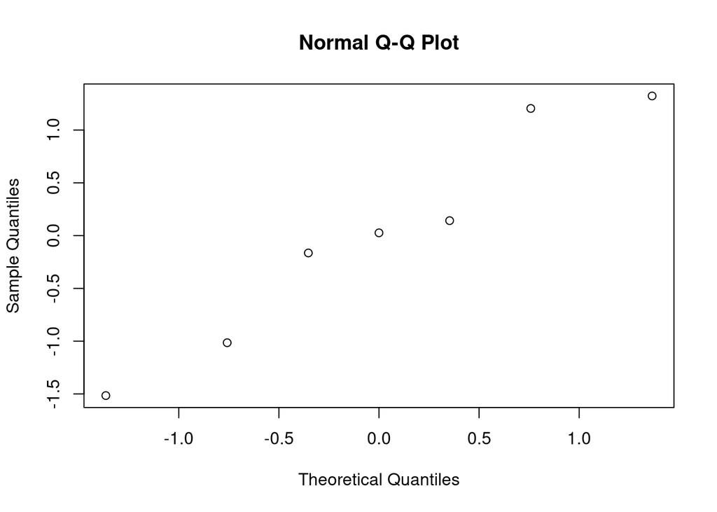

```r
qqnorm(model_residuals)
```

Algumas colunas de dados desnecessárias para análise de correlação são removidas com operador de colchetes e um data frame é criado com a função as.data.frame.

```r
td <- tptrgb[,c(-1, -2, -7)]
```

Verificando o objeto.

```r
td
```

```
##  class       : SpatVector
##  geometry    : points
##  dimensions  : 7, 4  (geometries, attributes)
##  extent      : 503007.7, 503018.1, 7652744, 7652756  (xmin, xmax, ymin, ymax)
##  source      : tpt.shp
##  coord. ref. : WGS 84 / UTM zone 23S (EPSG:32723)
##  names       : temperatur     R     G     B
##  type        :      <num> <num> <num> <num>
##  values      :       31.5   148    17   137
##                      29.1    84    17   141
##                      34.3   186    27   135
```

Definindo o objeto “td” como um data frame

```r
td <- as.data.frame(td)
```

Verificando o objeto criado.

```r
td
```

```
##   temperatur   R  G   B
## 1       31.5 148 17 137
## 2       29.1  84 17 141
## 3       34.3 186 27 135
## 4       29.7  27 18  73
## 5       33.5 203 37 110
## 6       32.3  66 22 117
## 7       40.7 210 86  22
```

A matriz de correlação entre temperatura do ar e bandas R, G, B foi determinada com a função cor.

```r
corr_matrix <- round(cor(td), 2)
```

Verificando o objeto criado.

```r
corr_matrix
```

```
##            temperatur     R     G     B
## temperatur       1.00  0.74  0.94 -0.68
## R                0.74  1.00  0.63 -0.17
## G                0.94  0.63  1.00 -0.82
## B               -0.68 -0.17 -0.82  1.00
```

Os resultados são apresentados de forma gráfica com a função ggcorrplot. Nesse caso, houve maior correlação da banda G com os dados de temperatura do ar.

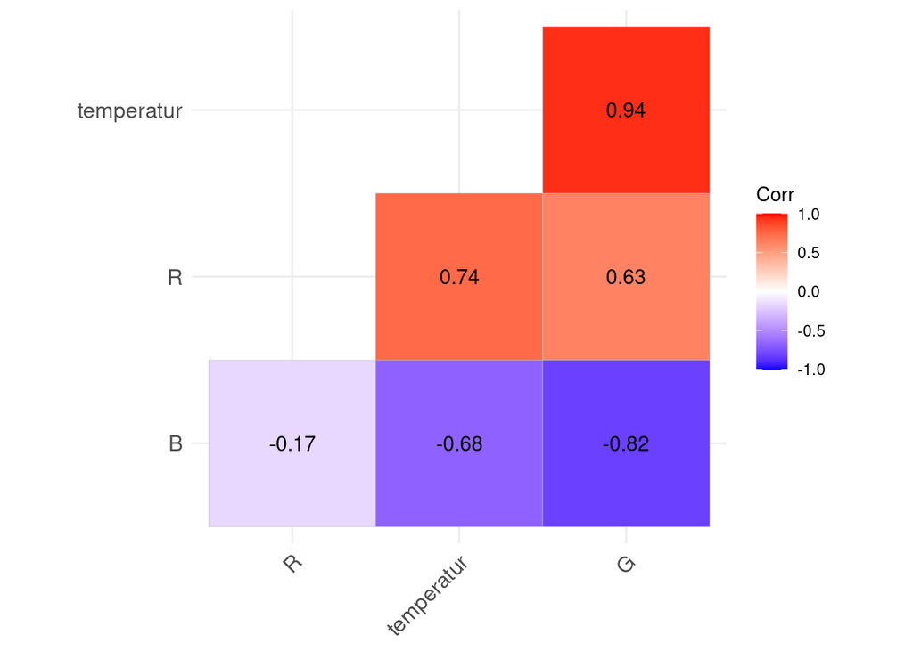

```r
ggcorrplot(corr_matrix, hc.order = TRUE, type = "lower",
          lab = TRUE)
```

Os resultados da modelagem são utilizados para predição espacial da temperatura do ar na imagem de temperatura radiométrica com a função predict.

```r
t <- predict(termal, model)
```

Verificando o objeto criado.

```r
t
```

```
## class       : SpatRaster
## dimensions  : 4070, 4223, 1  (nrow, ncol, nlyr)
## resolution  : 0.04999767, 0.04999282  (x, y)
## extent      : 502940, 503151.1, 7652677, 7652880  (xmin, xmax, ymin, ymax)
## coord. ref. : WGS 84 / UTM zone 23S (EPSG:32723)
## source(s)   : memory
## name        :     lyr1
## min value   : 26.99203
## max value   : 63.02232
```

Os resultados de temperatura do ar são delimitados ao redor da lavoura cafeeira com a função crop e argumento mask=TRUE.

```r
term <- crop(t, pol, mask = TRUE)
```

Verificando o objeto.

```r
term
```

```
## class       : SpatRaster
## dimensions  : 1833, 1878, 1  (nrow, ncol, nlyr)
## resolution  : 0.04999767, 0.04999282  (x, y)
## extent      : 502994.5, 503088.4, 7652743, 7652834  (xmin, xmax, ymin, ymax)
## coord. ref. : WGS 84 / UTM zone 23S (EPSG:32723)
## source(s)   : memory
## name        :     lyr1
## min value   : 27.40364
## max value   : 63.02232
```

O mapeamento da temperatura do ar em Cº na área de interesse é realizado com a função plot.

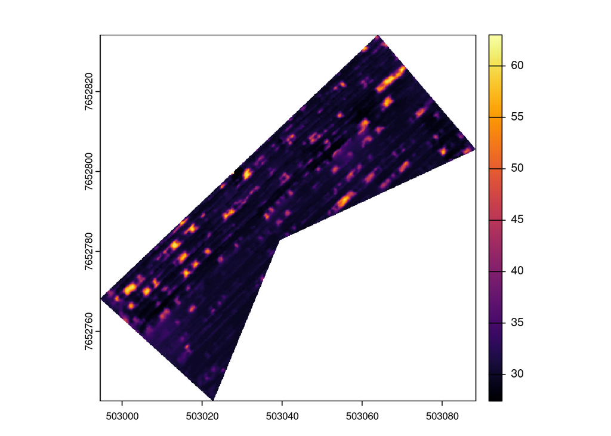

```r
plot(term, col = inferno(256))
```

## Referência

Alboukadel Kassambara (2023). ggcorrplot: Visualization of a Correlation Matrix using ‘ggplot2’. R package version 0.1.4.1. https://CRAN.R-project.org/package=ggcorrplot  
H. Wickham. ggplot2: Elegant Graphics for Data Analysis. Springer-Verlag New York, 2016.  
Robert J. Hijmans (2023). terra: Spatial Data Analysis. R package version 1.7-62. https://rspatial.org/  
Simon Garnier, Noam Ross, Robert Rudis, Antônio P. Camargo, Marco Sciaini, and Cédric Scherer (2023). viridis(Lite) - Colorblind-Friendly Color Maps for R. viridis package version 0.6.4.